# GRA4158 Marketing - Analysis of Experiments, Portfolio 3

Author

Vilijam Cekov, Luiz Felipe De Souza Simao

# Import Data

```r
casedata_task3 <- read.csv("CaseData_Task3.csv", stringsAsFactors = FALSE)

# Display the structure of the data to verify column names
str(casedata_task3)
```

```
'data.frame':   5000 obs. of  22 variables:
 $ X1 : num  23.8 21 22.8 25.8 22.9 24.9 24.1 21.4 24.8 23.8 ...
 $ X2 : num  13.7 14.4 11.5 13.5 13.6 12.9 11.8 12.4 14.2 15.9 ...
 $ X3 : num  22.5 21.5 20.6 22.7 21.6 19.4 22.9 19.5 21.6 23.4 ...
 $ X4 : num  16.2 14.5 14.7 15.8 17.5 13.8 17 13.8 15.5 16.8 ...
 $ X5 : int  0 0 0 1 1 0 1 0 0 1 ...
 $ X6 : num  22.9 23.4 20.2 22.5 23.5 21.1 24.6 20 23.9 20 ...
 $ X7 : num  11.6 11.2 9.6 11.5 12.7 9.6 12.9 9.5 11.4 9.2 ...
 $ X8 : num  10.1 12.8 9.7 10.3 12.3 6.3 9.6 7.4 10.6 11.9 ...
 $ X9 : num  18.9 20.2 19 21.9 19.7 15 20.2 17.1 23.8 20.2 ...
 $ X10: num  14.6 13 15.1 18.1 13.7 11.4 15.2 10.3 19.7 14.2 ...
 $ X11: num  13.1 13.7 14.6 14.2 14.5 12 14.1 11.4 16.4 13.6 ...
 $ X12: num  6.2 5.5 6.6 5.3 6.7 3.8 5.9 5 8.8 6.5 ...
 $ X13: num  14 13.5 16.6 13.3 14.8 11.8 13.8 12.9 15.2 15.3 ...
 $ X14: num  5.4 3.7 7.3 4.1 4.2 4.4 4.5 3.7 5.1 5.4 ...
 $ X15: num  11.6 9 13.4 10.2 10.5 10.6 11.8 9.6 11.8 11.7 ...
 $ X16: num  10.9 9.9 12.4 10.6 10.2 9.2 11.2 8.9 11 11.7 ...
 $ X17: num  12 12.4 13.3 11.1 11.8 10.7 12.6 12 11.7 12.9 ...
 $ X18: num  8.6 7.4 8.1 5.9 8.5 6.8 7.5 7.1 6.6 8.1 ...
 $ X19: num  12.3 12.1 11.8 10.3 12.8 10.2 11.1 10.8 11 12 ...
 $ X20: int  0 0 1 1 0 1 0 0 1 0 ...
 $ y  : int  1463 2410 659 2202 2196 2329 1993 2467 1644 1499 ...
 $ d  : int  0 1 1 1 0 1 1 1 0 1 ...
```

```r
# Check the first few rows
head(casedata_task3)
```

```
    X1   X2   X3   X4 X5   X6   X7   X8   X9  X10  X11 X12  X13 X14  X15  X16
1 23.8 13.7 22.5 16.2  0 22.9 11.6 10.1 18.9 14.6 13.1 6.2 14.0 5.4 11.6 10.9
2 21.0 14.4 21.5 14.5  0 23.4 11.2 12.8 20.2 13.0 13.7 5.5 13.5 3.7  9.0  9.9
3 22.8 11.5 20.6 14.7  0 20.2  9.6  9.7 19.0 15.1 14.6 6.6 16.6 7.3 13.4 12.4
4 25.8 13.5 22.7 15.8  1 22.5 11.5 10.3 21.9 18.1 14.2 5.3 13.3 4.1 10.2 10.6
5 22.9 13.6 21.6 17.5  1 23.5 12.7 12.3 19.7 13.7 14.5 6.7 14.8 4.2 10.5 10.2
6 24.9 12.9 19.4 13.8  0 21.1  9.6  6.3 15.0 11.4 12.0 3.8 11.8 4.4 10.6  9.2
   X17 X18  X19 X20    y d
1 12.0 8.6 12.3   0 1463 0
2 12.4 7.4 12.1   0 2410 1
3 13.3 8.1 11.8   1  659 1
4 11.1 5.9 10.3   1 2202 1
5 11.8 8.5 12.8   0 2196 0
6 10.7 6.8 10.2   1 2329 1
```

# Estimate the treatment effect using simple linear Regression Adjustment

The estimate for the discount coefficient is the Regression Adjustment ATE

```r
model_adj <- lm(y ~ d + X1 + X2 + X3 + X4 + X5 + X6 + X7 + X8 + X9 + X10 +
                 X11 + X12 + X13 + X14 + X15 + X16 + X17 + X18 + X19 + X20,
                 data = casedata_task3)

summary(model_adj)
```

```
Call:
lm(formula = y ~ d + X1 + X2 + X3 + X4 + X5 + X6 + X7 + X8 +
    X9 + X10 + X11 + X12 + X13 + X14 + X15 + X16 + X17 + X18 +
    X19 + X20, data = casedata_task3)

Residuals:
    Min      1Q  Median      3Q     Max
-623.40 -102.33    2.64  100.95  521.46

Coefficients:
             Estimate Std. Error t value Pr(>|t|)
(Intercept) 4697.0456    74.9246  62.690  < 2e-16 ***
d             15.1536     5.7042   2.657  0.00792 **
X1             3.0618     1.5140   2.022  0.04320 *
X2            -1.5605     1.8347  -0.851  0.39506
X3             1.3632     1.8200   0.749  0.45391
X4            -2.8476     1.7061  -1.669  0.09516 .
X5            36.2410     5.7218   6.334 2.60e-10 ***
X6            -1.7214     1.7192  -1.001  0.31673
X7            21.8707     1.8286  11.960  < 2e-16 ***
X8            -1.3171     1.8629  -0.707  0.47958
X9             0.8756     1.8314   0.478  0.63260
X10           -1.3391     1.8718  -0.715  0.47440
X11           -0.1072     3.7165  -0.029  0.97700
X12            1.2723     4.1530   0.306  0.75935
X13           -7.1754     3.6384  -1.972  0.04865 *
X14         -304.0026     3.6275 -83.805  < 2e-16 ***
X15         -133.6610     3.7419 -35.720  < 2e-16 ***
X16            0.5139     3.6869   0.139  0.88916
X17            1.5268     3.7039   0.412  0.68019
X18           -1.8884     3.6940  -0.511  0.60923
X19            0.8743     3.3074   0.264  0.79153
X20          -26.9651     5.3907  -5.002 5.87e-07 ***
---
Signif. codes:  0 '***' 0.001 '**' 0.01 '*' 0.05 '.' 0.1 ' ' 1

Residual standard error: 152.5 on 4978 degrees of freedom
Multiple R-squared:  0.8826,    Adjusted R-squared:  0.8821
F-statistic:  1782 on 21 and 4978 DF,  p-value: < 2.2e-16
```

Extract the ATE value from the regression and calculate robust standard errors using the HC3 estimator, which is more reliable in small samples and with heteroskedasticity.

```r
coeftest(model_adj, vcov = vcovHC(model_adj, type = "HC3"))
```

```
t test of coefficients:

              Estimate Std. Error  t value  Pr(>|t|)
(Intercept) 4697.04561   76.15859  61.6745 < 2.2e-16 ***
d             15.15365    5.80286   2.6114  0.009044 **
X1             3.06184    1.51318   2.0235  0.043080 *
X2            -1.56049    1.81397  -0.8603  0.389687
X3             1.36316    1.83034   0.7448  0.456453
X4            -2.84763    1.74765  -1.6294  0.103291
X5            36.24104    5.67533   6.3857 1.861e-10 ***
X6            -1.72139    1.71427  -1.0042  0.315354
X7            21.87065    1.79930  12.1551 < 2.2e-16 ***
X8            -1.31713    1.85035  -0.7118  0.476607
X9             0.87561    1.80426   0.4853  0.627484
X10           -1.33908    1.86892  -0.7165  0.473716
X11           -0.10716    3.77342  -0.0284  0.977345
X12            1.27229    4.16008   0.3058  0.759745
X13           -7.17543    3.72007  -1.9288  0.053807 .
X14         -304.00261    3.64002 -83.5167 < 2.2e-16 ***
X15         -133.66096    3.78412 -35.3216 < 2.2e-16 ***
X16            0.51387    3.54850   0.1448  0.884863
X17            1.52685    3.65959   0.4172  0.676537
X18           -1.88837    3.63423  -0.5196  0.603362
X19            0.87427    3.36898   0.2595  0.795255
X20          -26.96513    5.41454  -4.9801 6.569e-07 ***
---
Signif. codes:  0 '***' 0.001 '**' 0.01 '*' 0.05 '.' 0.1 ' ' 1
```

```r
ate <- coef(model_adj)["d"]
cat("The estimated Average Treatment Effect (ATE) for the treatment is:", ate, "\n")
```

```
The estimated Average Treatment Effect (ATE) for the treatment is: 15.15365
```

# Matching comparisons

Preparing the data for matching excersises

```r
ps_formula <- d ~ X1 + X2 + X3 + X4 + X5 + X6 + X7 + X8 + X9 + X10 + X11 +
X12 + X13 + X14 + X15 + X16 + X17 + X18 + X19 + X20
```

## 1:1 Nearest Neighbor Matching WITHOUT Replacement

```r
match_no_replace <- matchit(ps_formula,
                            data = casedata_task3,
                            method = "nearest",
                            distance = "glm",   # Uses logistic regression for propensity scores
                            replace = FALSE,    # Without replacement
                            ratio = 1)          # 1:1 matching

# View a summary to check covariate balance (ideally Std. Mean Diff < 0.1)
cat("Balance Summary (Without Replacement):\n")
```

```
Balance Summary (Without Replacement):
```

```r
print(summary(match_no_replace, un = FALSE))
```

```
Call:
matchit(formula = ps_formula, data = casedata_task3, method = "nearest",
    distance = "glm", replace = FALSE, ratio = 1)

Summary of Balance for Matched Data:
         Means Treated Means Control Std. Mean Diff. Var. Ratio eCDF Mean
distance        0.7342        0.2657          1.9201     0.9190    0.3878
X1             24.0591       24.0637         -0.0023     0.9305    0.0067
X2             14.1096       14.0910          0.0093     0.9578    0.0048
X3             22.0102       22.0009          0.0047     0.9816    0.0027
X4             15.7842       15.7595          0.0125     0.9536    0.0041
X5              0.5417        0.5324          0.0187          .    0.0093
X6             23.0879       23.0536          0.0173     0.9687    0.0039
X7             11.4389       11.3466          0.0462     1.0201    0.0073
X8             10.4588       10.2308          0.1115     1.0419    0.0180
X9             20.1062       20.4062         -0.1476     0.9862    0.0230
X10            14.7843       15.6086         -0.4177     1.0232    0.0640
X11            13.7279       14.4796         -0.8253     0.9879    0.1073
X12             5.7278        6.8929         -1.5370     1.0032    0.1738
X13            13.9400       14.7616         -0.9285     0.9906    0.1173
X14             4.9429        5.5103         -0.5895     1.0138    0.0846
X15            11.4658       11.8530         -0.3924     1.0262    0.0570
X16            11.3215       11.5974         -0.2730     1.0655    0.0386
X17            12.3863       12.5703         -0.1844     1.0055    0.0270
X18             7.8680        8.0111         -0.1386     1.0906    0.0202
X19            11.5044       11.5751         -0.0687     1.0678    0.0108
X20             0.3464        0.3493         -0.0060          .    0.0028
         eCDF Max Std. Pair Dist.
distance   0.6293          1.9201
X1         0.0259          1.1445
X2         0.0158          1.1531
X3         0.0105          1.1438
X4         0.0138          1.1503
X5         0.0093          0.9881
X6         0.0170          1.1274
X7         0.0251          1.1152
X8         0.0559          1.1007
X9         0.0713          1.1326
X10        0.1848          1.1405
X11        0.3205          1.2056
X12        0.5543          1.5408
X13        0.3553          1.2431
X14        0.2459          1.1738
X15        0.1572          1.1387
X16        0.1155          1.1115
X17        0.0729          1.1178
X18        0.0583          1.0849
X19        0.0344          1.0910
X20        0.0028          0.9580

Sample Sizes:
          Control Treated
All          2532    2468
Matched      2468    2468
Unmatched      64       0
Discarded       0       0
```

```r
# Extract the matched dataset
data_matched_no_replace <- match.data(match_no_replace)

# Estimate the Treatment Effect
# We include the covariates in the final outcome model to make it "doubly robust"
model_no_replace <- lm(y ~ d + X1 + X2 + X3 + X4 + X5 + X6 + X7 + X8 + X9 + X10 + X11 + X12 +
                       X13 + X14 + X15 + X16 + X17 + X18 + X19 + X20,
                       data = data_matched_no_replace,
                       weights = weights)
```

Looking at the balance table, the results are not great. Many covariates still have SMDs well above 0.1 – X12 is at −1.54, X11 at −0.83, X13 at −0.93. The propensity score distance SMD is 1.92, which is quite high. So even after matching, the treated and control groups still look pretty different on these variables. We think this happens because without replacement, once a good control unit gets matched it’s gone, and later treated units get stuck with worse matches. This makes us less confident in the ATT from this specification.

Extract the ATT value and calculate robust standard errors using Variance/Covariance Heteroscedasticity-Consistent matrix estimation, which is used to adjust the standard errors of the estimated treatment effects to account for the matched data structure and potential heteroscedasticity.

```r
# Calculate robust standard errors
print(coeftest(model_no_replace, vcov. = vcovHC))
```

```
t test of coefficients:

              Estimate Std. Error  t value  Pr(>|t|)
(Intercept) 4662.91246   76.89579  60.6394 < 2.2e-16 ***
d             17.15026    5.83088   2.9413  0.003284 **
X1             3.06093    1.51975   2.0141  0.044053 *
X2            -1.43813    1.82390  -0.7885  0.430447
X3             1.29676    1.84075   0.7045  0.481171
X4            -2.86753    1.75898  -1.6302  0.103118
X5            36.29551    5.71131   6.3550 2.272e-10 ***
X6            -1.51569    1.71731  -0.8826  0.377500
X7            21.90153    1.80833  12.1115 < 2.2e-16 ***
X8            -1.77083    1.86226  -0.9509  0.341699
X9             0.87361    1.80706   0.4834  0.628801
X10           -1.51174    1.88125  -0.8036  0.421678
X11            0.87193    3.79489   0.2298  0.818284
X12            2.95103    4.24587   0.6950  0.487066
X13           -6.47073    3.73861  -1.7308  0.083553 .
X14         -304.35470    3.65250 -83.3277 < 2.2e-16 ***
X15         -133.08910    3.80349 -34.9913 < 2.2e-16 ***
X16            0.77594    3.58534   0.2164  0.828669
X17            1.03521    3.69715   0.2800  0.779487
X18           -1.56797    3.65007  -0.4296  0.667525
X19            0.66176    3.39599   0.1949  0.845507
X20          -27.64769    5.43725  -5.0849 3.816e-07 ***
---
Signif. codes:  0 '***' 0.001 '**' 0.01 '*' 0.05 '.' 0.1 ' ' 1
```

```r
att <- coef(model_no_replace)["d"]
cat("The estimated Average Treatment Effect on the Treated for the treatment is (ATT):", att, "\n")
```

```
The estimated Average Treatment Effect on the Treated for the treatment is (ATT): 17.15026
```

## 1:1 Nearest Neighbor Matching WITH Replacement

```r
match_with_replace <- matchit(ps_formula,
                              data = casedata_task3,
                              method = "nearest",
                              distance = "glm",
                              replace = TRUE,     # With replacement
                              ratio = 1)

# View a summary to check covariate balance
cat("Balance Summary (With Replacement):\n")
```

```
Balance Summary (With Replacement):
```

```r
print(summary(match_with_replace, un = FALSE))
```

```
Call:
matchit(formula = ps_formula, data = casedata_task3, method = "nearest",
    distance = "glm", replace = TRUE, ratio = 1)

Summary of Balance for Matched Data:
         Means Treated Means Control Std. Mean Diff. Var. Ratio eCDF Mean
distance        0.7342        0.7341          0.0005     0.9942    0.0012
X1             24.0591       24.0335          0.0129     0.8633    0.0137
X2             14.1096       14.0685          0.0206     0.8747    0.0153
X3             22.0102       22.0362         -0.0130     0.8053    0.0165
X4             15.7842       15.7235          0.0308     0.9084    0.0116
X5              0.5417        0.5211          0.0415          .    0.0207
X6             23.0879       22.8316          0.1293     0.9564    0.0208
X7             11.4389       10.9902          0.2247     1.1376    0.0358
X8             10.4588        9.9677          0.2401     1.1778    0.0396
X9             20.1062       19.7199          0.1901     0.9503    0.0292
X10            14.7843       14.5226          0.1326     1.0423    0.0210
X11            13.7279       13.7266          0.0014     1.1714    0.0111
X12             5.7278        5.6479          0.1055     0.8326    0.0147
X13            13.9400       13.8658          0.0838     1.0795    0.0146
X14             4.9429        4.8341          0.1131     0.9741    0.0167
X15            11.4658       11.3919          0.0749     1.0047    0.0125
X16            11.3215       11.3739         -0.0518     0.9714    0.0117
X17            12.3863       12.3467          0.0398     0.8209    0.0143
X18             7.8680        7.7625          0.1022     0.8899    0.0170
X19            11.5044       11.5057         -0.0013     1.0171    0.0116
X20             0.3464        0.3343          0.0255          .    0.0122
         eCDF Max Std. Pair Dist.
distance   0.0425          0.0027
X1         0.0506          1.1746
X2         0.0523          1.1719
X3         0.0434          1.2037
X4         0.0442          1.1883
X5         0.0207          0.9946
X6         0.0754          1.1502
X7         0.1333          1.1094
X8         0.1264          1.1154
X9         0.1017          1.1269
X10        0.0940          1.0668
X11        0.0425          0.9713
X12        0.0604          0.5051
X13        0.0600          0.9414
X14        0.0802          1.0369
X15        0.0758          1.0793
X16        0.0506          1.1028
X17        0.0409          1.1375
X18        0.0681          1.1460
X19        0.0470          1.1050
X20        0.0122          0.9179

Sample Sizes:
              Control Treated
All           2532.      2468
Matched (ESS)  139.53    2468
Matched        707.      2468
Unmatched     1825.         0
Discarded        0.         0
```

```r
# Extract the matched dataset
data_matched_with_replace <- get_matches(match_with_replace)

# Estimate the Treatment Effect
model_with_replace <- lm(y ~ d + X1 + X2 + X3 + X4 + X5 + X6 + X7 + X8 + X9 + X10 + X11 + X12 +
                         X13 + X14 + X15 + X16 + X17 + X18 + X19 + X20,
                         data = data_matched_with_replace,
                         weights = weights)
```

Extract the ATT value and calculate robust standard errors clustered by the matched pair ID (`subclass`), which accounts for the fact that some control units may be used multiple times as matches, leading to correlated errors within matched pairs.

```r
print(coeftest(model_with_replace, vcov. = vcovCL, cluster = ~subclass))
```

```
t test of coefficients:

              Estimate Std. Error  t value  Pr(>|t|)
(Intercept) 4397.39206   75.72990  58.0668 < 2.2e-16 ***
d             23.25309    4.38925   5.2977 1.224e-07 ***
X1             3.03662    1.44236   2.1053 0.0353144 *
X2            -2.50465    1.83192  -1.3672 0.1716165
X3             3.88159    1.83070   2.1203 0.0340329 *
X4            -1.66259    1.80731  -0.9199 0.3576577
X5            59.55033    5.81260  10.2450 < 2.2e-16 ***
X6            -5.88580    1.74421  -3.3745 0.0007453 ***
X7            18.50881    1.87071   9.8940 < 2.2e-16 ***
X8             3.07111    1.91503   1.6037 0.1088472
X9             0.44156    1.73320   0.2548 0.7989141
X10           -3.07928    1.86650  -1.6498 0.0990561 .
X11           11.14108    3.66045   3.0436 0.0023497 **
X12          -16.28603    3.85220  -4.2277 2.404e-05 ***
X13            4.06409    3.65274   1.1126 0.2659291
X14         -303.81083    3.75733 -80.8582 < 2.2e-16 ***
X15         -116.73137    4.03738 -28.9126 < 2.2e-16 ***
X16           -5.59644    3.63604  -1.5392 0.1238302
X17            0.87081    3.56892   0.2440 0.8072427
X18            4.16273    3.34672   1.2438 0.2136242
X19           -2.06649    3.37233  -0.6128 0.5400503
X20          -27.46830    5.55989  -4.9404 8.053e-07 ***
---
Signif. codes:  0 '***' 0.001 '**' 0.01 '*' 0.05 '.' 0.1 ' ' 1
```

```r
att <- coef(model_with_replace)["d"]
cat("The estimated Average Treatment Effect on the Treated for the treatment is (ATT):", att, "\n")
```

```
The estimated Average Treatment Effect on the Treated for the treatment is (ATT): 23.25309
```

## Euclidean Distance Matching

```r
euc_out <- matchit(
  d ~ X1 + X2 + X3 + X4 + X5 + X6 + X7 + X8 + X9 + X10 +
       X11 + X12 + X13 + X14 + X15 + X16 + X17 + X18 + X19 + X20,
  data = casedata_task3,
  method = "nearest",
  distance = "euclidean",
  normalize = TRUE
)

summary(euc_out)
```

```
Call:
matchit(formula = d ~ X1 + X2 + X3 + X4 + X5 + X6 + X7 + X8 +
    X9 + X10 + X11 + X12 + X13 + X14 + X15 + X16 + X17 + X18 +
    X19 + X20, data = casedata_task3, method = "nearest", distance = "euclidean",
    normalize = TRUE)

Summary of Balance for All Data:
    Means Treated Means Control Std. Mean Diff. Var. Ratio eCDF Mean eCDF Max
X1        24.0591       24.0646         -0.0028     0.9359    0.0063   0.0248
X2        14.1096       14.0950          0.0073     0.9616    0.0049   0.0155
X3        22.0102       22.0011          0.0046     0.9769    0.0029   0.0106
X4        15.7842       15.7626          0.0109     0.9435    0.0044   0.0134
X5         0.5417        0.5336          0.0164          .    0.0082   0.0082
X6        23.0879       23.0587          0.0147     0.9675    0.0036   0.0147
X7        11.4389       11.3458          0.0467     1.0213    0.0073   0.0240
X8        10.4588       10.2257          0.1140     1.0445    0.0184   0.0577
X9        20.1062       20.4252         -0.1570     0.9849    0.0245   0.0728
X10       14.7843       15.6430         -0.4351     1.0106    0.0667   0.1897
X11       13.7279       14.5120         -0.8609     0.9437    0.1119   0.3290
X12        5.7278        6.9410         -1.6004     0.8800    0.1809   0.5601
X13       13.9400       14.7973         -0.9687     0.9357    0.1224   0.3611
X14        4.9429        5.5363         -0.6165     0.9893    0.0884   0.2546
X15       11.4658       11.8701         -0.4097     1.0171    0.0595   0.1626
X16       11.3215       11.6137         -0.2891     1.0480    0.0408   0.1214
X17       12.3863       12.5792         -0.1933     0.9952    0.0283   0.0740
X18        7.8680        8.0182         -0.1455     1.0856    0.0212   0.0596
X19       11.5044       11.5839         -0.0772     1.0663    0.0121   0.0381
X20        0.3464        0.3468         -0.0007          .    0.0003   0.0003

Summary of Balance for Matched Data:
    Means Treated Means Control Std. Mean Diff. Var. Ratio eCDF Mean eCDF Max
X1        24.0591       24.0653         -0.0032     0.9349    0.0064   0.0243
X2        14.1096       14.0893          0.0102     0.9621    0.0045   0.0158
X3        22.0102       21.9816          0.0144     0.9787    0.0034   0.0122
X4        15.7842       15.7383          0.0232     0.9592    0.0046   0.0162
X5         0.5417        0.5304          0.0228          .    0.0113   0.0113
X6        23.0879       23.0280          0.0302     0.9705    0.0052   0.0211
X7        11.4389       11.3074          0.0659     1.0282    0.0103   0.0320
X8        10.4588       10.1615          0.1453     1.0810    0.0232   0.0681
X9        20.1062       20.3464         -0.1182     1.0326    0.0185   0.0608
```

[output cut: 24 more lines]

```
X13          1.1450
X14          0.8978
X15          0.7994
X16          0.7349
X17          0.7004
X18          0.6556
X19          0.7062
X20          0.6667

Sample Sizes:
          Control Treated
All          2532    2468
Matched      2468    2468
Unmatched      64       0
Discarded       0       0
```

```r
# bal.tab(euc_out) - balance info already shown in summary above

m_data_euc <- match.data(euc_out)
lm_euc <- lm(y ~ d + X1 + X2 + X3 + X4 + X5 + X6 + X7 + X8 + X9 + X10 + X11 + X12 + X13 + X14 +
             X15 + X16 + X17 + X18 + X19 + X20,
             data = m_data_euc, weights = weights)
```

Extract the ATT value and calculate robust standard errors using the HC3 estimator

```r
summary(lm_euc)
```

```
Call:
lm(formula = y ~ d + X1 + X2 + X3 + X4 + X5 + X6 + X7 + X8 +
    X9 + X10 + X11 + X12 + X13 + X14 + X15 + X16 + X17 + X18 +
    X19 + X20, data = m_data_euc, weights = weights)

Residuals:
    Min      1Q  Median      3Q     Max
-616.05 -102.44    2.86  101.41  524.23

Coefficients:
             Estimate Std. Error t value Pr(>|t|)
(Intercept) 4648.7680    75.9523  61.206  < 2e-16 ***
d             16.1581     5.7160   2.827  0.00472 **
X1             3.1540     1.5220   2.072  0.03829 *
X2            -1.8180     1.8464  -0.985  0.32485
X3             1.4143     1.8322   0.772  0.44021
X4            -2.5653     1.7223  -1.489  0.13643
X5            35.9792     5.7585   6.248 4.51e-10 ***
X6            -1.5523     1.7297  -0.897  0.36952
X7            22.1400     1.8412  12.024  < 2e-16 ***
X8            -1.7048     1.8770  -0.908  0.36379
X9             1.1399     1.8412   0.619  0.53587
X10           -1.4086     1.8840  -0.748  0.45470
X11            0.1835     3.7463   0.049  0.96094
X12            1.8764     4.1877   0.448  0.65412
X13           -6.1732     3.6572  -1.688  0.09148 .
X14         -303.7276     3.6391 -83.461  < 2e-16 ***
X15         -133.2866     3.7555 -35.491  < 2e-16 ***
X16            1.1361     3.7119   0.306  0.75956
X17            1.4198     3.7307   0.381  0.70354
X18           -1.8636     3.7137  -0.502  0.61581
X19            1.1463     3.3272   0.345  0.73047
X20          -27.2010     5.4148  -5.023 5.26e-07 ***
---
Signif. codes:  0 '***' 0.001 '**' 0.01 '*' 0.05 '.' 0.1 ' ' 1

Residual standard error: 152.3 on 4914 degrees of freedom
Multiple R-squared:  0.8794,    Adjusted R-squared:  0.8789
F-statistic:  1707 on 21 and 4914 DF,  p-value: < 2.2e-16
```

```r
cat("\nRobust Standard Errors (Euclidean Matching):\n")
```

```
Robust Standard Errors (Euclidean Matching):
```

```r
print(coeftest(lm_euc, vcov. = vcovHC(lm_euc, type = "HC3")))
```

```
t test of coefficients:

              Estimate Std. Error  t value  Pr(>|t|)
(Intercept) 4648.76805   76.81149  60.5218 < 2.2e-16 ***
d             16.15806    5.80282   2.7845  0.005381 **
X1             3.15400    1.52077   2.0740  0.038136 *
X2            -1.81799    1.82728  -0.9949  0.319827
X3             1.41426    1.84326   0.7673  0.442965
X4            -2.56528    1.76488  -1.4535  0.146144
X5            35.97922    5.71258   6.2982 3.273e-10 ***
X6            -1.55231    1.72393  -0.9004  0.367926
X7            22.13995    1.80807  12.2451 < 2.2e-16 ***
X8            -1.70481    1.86583  -0.9137  0.360918
X9             1.13992    1.81094   0.6295  0.529076
X10           -1.40860    1.88081  -0.7489  0.453934
X11            0.18347    3.80193   0.0483  0.961513
X12            1.87635    4.18418   0.4484  0.653856
X13           -6.17320    3.73096  -1.6546  0.098072 .
X14         -303.72759    3.64576 -83.3099 < 2.2e-16 ***
X15         -133.28657    3.80374 -35.0410 < 2.2e-16 ***
X16            1.13611    3.57993   0.3174  0.750988
X17            1.41977    3.69012   0.3847  0.700440
X18           -1.86365    3.64649  -0.5111  0.609318
X19            1.14632    3.38243   0.3389  0.734697
X20          -27.20100    5.44296  -4.9975 6.010e-07 ***
---
Signif. codes:  0 '***' 0.001 '**' 0.01 '*' 0.05 '.' 0.1 ' ' 1
```

### Comparing matching quality across methods

On common support: the sample sizes tables show that 64 control units (out of 2532) went unmatched, meaning they had no reasonably close treated counterpart. No treated units were discarded. So we’re not losing a huge chunk of the data, which is reassuring – but the fact that those 64 controls couldn’t find a match does hint at the limited overlap between the groups, which is also visible in the propensity score density plot in the IPW section. The separation in that plot explains why both the matching balance and the IPW weights struggle here.

# Inverse Probability Weighting (IPW)

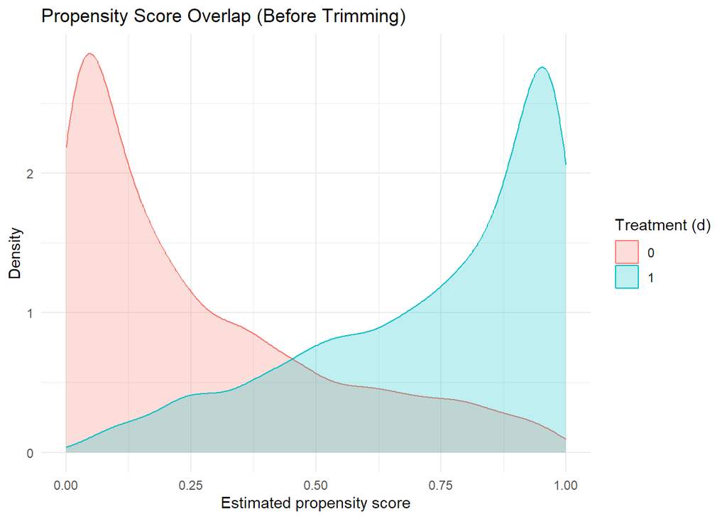

```r
# Complete-case sample for IPW variables
ipw_vars <- c("y", "d", paste0("X", 1:20))
df_ipw <- casedata_task3[complete.cases(casedata_task3[, ipw_vars]), ]

# 1) Estimate propensity scores with logistic regression
ps_model <- glm(
  d ~ X1 + X2 + X3 + X4 + X5 + X6 + X7 + X8 + X9 + X10 +
      X11 + X12 + X13 + X14 + X15 + X16 + X17 + X18 + X19 + X20,
  data = df_ipw,
  family = binomial(link = "logit")
)

df_ipw$ps <- predict(ps_model, type = "response")

# Overlap/common support diagnostic BEFORE trimming
ggplot(df_ipw, aes(x = ps, color = factor(d), fill = factor(d))) +
  geom_density(alpha = 0.25) +
  labs(
    title = "Propensity Score Overlap (Before Trimming)",
    x = "Estimated propensity score",
    y = "Density",
    color = "Treatment (d)",
    fill = "Treatment (d)"
  ) +
  theme_minimal()
```

```r
# 2) Trim propensity scores to reduce extreme weights under weak overlap
df_ipw$ps_trim <- pmin(pmax(df_ipw$ps, 0.01), 0.99)

# Function requested in prompt: two-step IPW ATE with logistic PS + trimming
estimate_ipw_ate <- function(data, trim = 0.01) {
  ps_fit <- glm(
    d ~ X1 + X2 + X3 + X4 + X5 + X6 + X7 + X8 + X9 + X10 +
      X11 + X12 + X13 + X14 + X15 + X16 + X17 + X18 + X19 + X20,
    data = data,
    family = binomial(link = "logit")
  )

  ps_hat <- predict(ps_fit, newdata = data, type = "response")
  ps_hat <- pmin(pmax(ps_hat, trim), 1 - trim)

  mean(data$y * (data$d / ps_hat - (1 - data$d) / (1 - ps_hat)))
}

# 3) Manual IPW ATE using slide formula:
#    ATE = mean( y * ( d/ps - (1-d)/(1-ps) ) )
ate_ipw_manual <- estimate_ipw_ate(df_ipw, trim = 0.01)

cat("\nManual IPW ATE (primary estimate):", round(ate_ipw_manual, 4), "\n")
```

```
Manual IPW ATE (primary estimate): -318.1235
```

```r
# 4) Bootstrap inference for the full two-step IPW estimator:
#    re-sample rows, re-estimate propensity model, re-calculate ATE each draw.
set.seed(123)
B_ipw <- 1000
n_ipw <- nrow(df_ipw)
boot_ipw_ate <- numeric(B_ipw)

for (b in seq_len(B_ipw)) {
  idx <- sample.int(n_ipw, size = n_ipw, replace = TRUE)
  boot_data <- df_ipw[idx, ]
  boot_ipw_ate[b] <- estimate_ipw_ate(boot_data, trim = 0.01)
}

ipw_boot_mean <- mean(boot_ipw_ate)
ipw_boot_se <- sd(boot_ipw_ate)
ipw_boot_ci <- quantile(boot_ipw_ate, probs = c(0.025, 0.975))

cat("Bootstrap mean (IPW):", round(ipw_boot_mean, 4), "\n")
```

```
Bootstrap mean (IPW): -315.5704
```

```r
cat("Bootstrap SE (IPW):", round(ipw_boot_se, 4), "\n")
```

```
Bootstrap SE (IPW): 81.2465
```

```r
cat("95% percentile CI (IPW): [", round(ipw_boot_ci[1], 4), ",", round(ipw_boot_ci[2], 4), "]\n")
```

```
95% percentile CI (IPW): [ -487.5767 , -173.1673 ]
```

```r
# 5) Secondary comparison: IPW weighted regression-adjustment model
df_ipw$ipw_weight <- ifelse(df_ipw$d == 1,
                            1 / df_ipw$ps_trim,
                            1 / (1 - df_ipw$ps_trim))

cat("\nInverse Probability Weights Summary:\n")
```

```
Inverse Probability Weights Summary:
```

```r
summary(df_ipw$ipw_weight)
```

```
   Min. 1st Qu.  Median    Mean 3rd Qu.    Max.
  1.010   1.059   1.216   1.972   1.708 100.000
```

```r
lm_ipw <- lm(y ~ d + X1 + X2 + X3 + X4 + X5 + X6 + X7 + X8 + X9 + X10 + X11 + X12 + X13 + X14 + X15 + X16 + X17 + X18 + X19 + X20,
             data = df_ipw, weights = ipw_weight)

cat("\nSecondary comparison: weighted lm IPW-RA model\n")
```

```
Secondary comparison: weighted lm IPW-RA model
```

```r
print(summary(lm_ipw))
```

```
Call:
lm(formula = y ~ d + X1 + X2 + X3 + X4 + X5 + X6 + X7 + X8 +
    X9 + X10 + X11 + X12 + X13 + X14 + X15 + X16 + X17 + X18 +
    X19 + X20, data = df_ipw, weights = ipw_weight)

Weighted Residuals:
     Min       1Q   Median       3Q      Max
-2078.34  -118.35    10.78   128.11  1164.02

Coefficients:
             Estimate Std. Error t value Pr(>|t|)
(Intercept) 4590.0109    74.6317  61.502  < 2e-16 ***
d             15.8064     4.3103   3.667 0.000248 ***
X1            -0.2598     1.4704  -0.177 0.859763
X2             0.9350     1.8075   0.517 0.604976
X3             2.3339     1.7892   1.304 0.192136
X4            -3.0046     1.7406  -1.726 0.084373 .
X5            58.9206     5.7048  10.328  < 2e-16 ***
X6            -3.5986     1.7019  -2.114 0.034523 *
X7            20.1744     1.8480  10.917  < 2e-16 ***
X8            -0.7299     1.8412  -0.396 0.691829
X9             2.6665     1.8280   1.459 0.144698
X10           -1.1871     1.8626  -0.637 0.523939
X11            2.3650     3.6798   0.643 0.520437
X12           -3.9171     3.7564  -1.043 0.297095
X13           -4.4726     3.6656  -1.220 0.222462
X14         -308.5079     3.7113 -83.127  < 2e-16 ***
X15         -122.9808     3.8228 -32.170  < 2e-16 ***
X16            2.2777     3.7034   0.615 0.538567
X17           -4.1136     3.5600  -1.156 0.247939
X18           -2.1922     3.5469  -0.618 0.536563
X19            4.5555     3.2707   1.393 0.163743
X20          -23.7826     5.4203  -4.388 1.17e-05 ***
---
Signif. codes:  0 '***' 0.001 '**' 0.01 '*' 0.05 '.' 0.1 ' ' 1

Residual standard error: 211.6 on 4978 degrees of freedom
Multiple R-squared:  0.889, Adjusted R-squared:  0.8885
F-statistic:  1898 on 21 and 4978 DF,  p-value: < 2.2e-16
```

```r
print(coeftest(lm_ipw, vcov. = vcovHC(lm_ipw, type = "HC3")))
```

```
t test of coefficients:

              Estimate Std. Error  t value  Pr(>|t|)
(Intercept) 4590.01087  131.68226  34.8567 < 2.2e-16 ***
d             15.80639    8.30433   1.9034  0.057047 .
X1            -0.25979    2.54310  -0.1022  0.918637
X2             0.93500    3.28803   0.2844  0.776141
X3             2.33393    3.63634   0.6418  0.521010
X4            -3.00456    3.21316  -0.9351  0.349793
X5            58.92058    9.94823   5.9227 3.379e-09 ***
X6            -3.59856    3.63202  -0.9908  0.321837
X7            20.17440    2.96300   6.8088 1.101e-11 ***
X8            -0.72987    3.38596  -0.2156  0.829343
X9             2.66654    3.20263   0.8326  0.405105
X10           -1.18711    3.30364  -0.3593  0.719361
X11            2.36505    5.89540   0.4012  0.688313
X12           -3.91711    5.88667  -0.6654  0.505812
X13           -4.47265    5.68332  -0.7870  0.431332
X14         -308.50795    6.23565 -49.4748 < 2.2e-16 ***
X15         -122.98077    6.88727 -17.8562 < 2.2e-16 ***
X16            2.27770    5.59034   0.4074  0.683705
X17           -4.11359    7.77266  -0.5292  0.596663
X18           -2.19218    6.65799  -0.3293  0.741977
X19            4.55546    5.93037   0.7682  0.442430
X20          -23.78255    8.47568  -2.8060  0.005036 **
---
Signif. codes:  0 '***' 0.001 '**' 0.01 '*' 0.05 '.' 0.1 ' ' 1
```

## IPW Critical Discussion Points

This is basically the classic problem with IPW – it’s very sensitive to poor overlap. The weighted regression version (~15.81) does much better because the regression component doesn’t rely purely on the weights. It also shows why AIPW and DML are generally more appealing: they don’t put all their eggs in the weighting basket.

# Augmented Inverse Probability Weighting (AIPW) - Manual Estimation

This section implements AIPW manually using the doubly robust score:

$$ATE = \frac{1}{N}\sum_{i=1}^{N} \left( \frac{T_i}{\hat{p}(X_i)}(Y_i - \hat{\mu}_{T=1}(X_i)) + \hat{\mu}_{T=1}(X_i) \right)
- \frac{1}{N}\sum_{i=1}^{N} \left( \frac{(1-T_i)}{1-\hat{p}(X_i)}(Y_i - \hat{\mu}_{T=0}(X_i)) + \hat{\mu}_{T=0}(X_i) \right)$$

```r
df <- casedata_task3
df$treatment <- df$d
df$sales <- df$y
covariates <- paste0("X", 1:20)

# Basic checks
stopifnot(all(c("treatment", "sales") %in% names(df)))
stopifnot(all(covariates %in% names(df)))
stopifnot(all(na.omit(unique(df$treatment)) %in% c(0, 1)))

# Keep complete cases for variables used in AIPW
aipw_vars <- c("treatment", "sales", covariates)
df_aipw <- df[complete.cases(df[, aipw_vars]), aipw_vars]

# AIPW function returning the sample ATE using the manual formula
estimate_aipw_ate <- function(data, covariate_names, trim = 0.01) {
  # 1) Selection model (propensity score): P(T=1|X)
  ps_formula <- as.formula(
    paste("treatment ~", paste(covariate_names, collapse = " + "))
  )
  ps_model <- glm(ps_formula, data = data, family = binomial(link = "logit"))
  p_hat <- predict(ps_model, newdata = data, type = "response")

  # Trimming avoids extreme inverse-probability weights when overlap is weak
  p_hat <- pmin(pmax(p_hat, trim), 1 - trim)

  # 2) Outcome models fitted separately by treatment arm
  mu1_formula <- as.formula(
    paste("sales ~", paste(covariate_names, collapse = " + "))
  )
  mu0_formula <- mu1_formula

  outcome_model_treated <- lm(mu1_formula, data = data[data$treatment == 1, ])
  outcome_model_control <- lm(mu0_formula, data = data[data$treatment == 0, ])

  # Predicted potential outcomes for every unit
  mu1_hat <- predict(outcome_model_treated, newdata = data)
  mu0_hat <- predict(outcome_model_control, newdata = data)

  # 3) Doubly robust correction terms:
  #    residuals (Y - mu_hat) are reweighted by inverse propensity scores.
  #    If either the PS model or the outcome models are correctly specified,
  #    the estimator remains consistent.
  score_treated <- (data$treatment / p_hat) * (data$sales - mu1_hat) + mu1_hat
  score_control <- ((1 - data$treatment) / (1 - p_hat)) * (data$sales - mu0_hat) + mu0_hat

  mean(score_treated) - mean(score_control)
}

# Point estimate
aipw_ate <- estimate_aipw_ate(df_aipw, covariates, trim = 0.01)
cat("Manual AIPW ATE estimate:", round(aipw_ate, 4), "\n")
```

```
Manual AIPW ATE estimate: 18.8487
```

```r
# 4) Bootstrap inference for AIPW
set.seed(123)
B <- 1000
n <- nrow(df_aipw)
boot_ate <- numeric(B)

for (b in seq_len(B)) {
  idx <- sample.int(n, size = n, replace = TRUE)
  boot_data <- df_aipw[idx, ]
  boot_ate[b] <- estimate_aipw_ate(boot_data, covariates, trim = 0.01)
}

aipw_se <- sd(boot_ate)
aipw_ci <- quantile(boot_ate, probs = c(0.025, 0.975))
aipw_boot_mean <- mean(boot_ate)

cat("Bootstrap mean (AIPW):", round(aipw_boot_mean, 4), "\n")
```

```
Bootstrap mean (AIPW): 19.2227
```

```r
cat("Bootstrap SE (AIPW):", round(aipw_se, 4), "\n")
```

```
Bootstrap SE (AIPW): 8.4778
```

```r
cat("95% Bootstrap CI (AIPW): [", round(aipw_ci[1], 4), ",", round(aipw_ci[2], 4), "]\n")
```

```
95% Bootstrap CI (AIPW): [ 2.1545 , 35.7856 ]
```

## AIPW Critical Discussion Points

- Doubly robust consistency: AIPW is consistent if either the propensity score model or the outcome regression models are correctly specified.
- Efficiency: Compared with simple IPW, AIPW is typically more stable and can achieve the semiparametric efficiency bound under correct specification.
- Debiasing logic: The residual-weighted terms, $(Y - \hat{\mu})$, correct the regression predictions using inverse-probability weighting.
- Overlap/common support: Propensity scores should stay away from 0 and 1; weak overlap creates extreme weights and unstable estimates, so diagnostics and trimming are important.

# Double Machine Learning (DML): PLR with Cross-Fitting

We now estimate the ATE with DoubleML using the partially linear regression model:

$$Y = \beta D + g(X) + \epsilon, \qquad D = m(X) + \xi$$

Cross-fitting (sample splitting) is used to reduce overfitting bias in nuisance estimation, and the orthogonal score makes the final $\beta$ less sensitive to small nuisance-model errors.

```r
# Data setup for DML
x_cols <- paste0("X", 1:20)
dml_vars <- c("y", "d", x_cols)
dml_df <- casedata_task3[complete.cases(casedata_task3[, dml_vars]), dml_vars]

# Binary treatment check
stopifnot(all(unique(dml_df$d) %in% c(0, 1)))

# DoubleML data backend
dml_data <- DoubleMLData$new(
  data = dml_df,
  y_col = "y",
  d_cols = "d",
  x_cols = x_cols
)

# Tasks for out-of-sample nuisance performance
# Use only X covariates as predictors to match DML nuisance definitions.
task_y_data <- dml_df[, c("y", x_cols)]
task_y <- TaskRegr$new(id = "outcome_task", backend = task_y_data, target = "y")

task_d_data <- dml_df[, x_cols]
task_d_data$d_factor <- factor(dml_df$d, levels = c(0, 1))
task_d <- TaskClassif$new(
  id = "treatment_task",
  backend = task_d_data,
  target = "d_factor",
  positive = "1"
)

# Helper to construct requested learners with a fallback if IDs differ by install
get_lrn <- function(primary_id, fallback_id = NULL, ...) {
  if (primary_id %in% mlr_learners$keys()) {
    return(lrn(primary_id, ...))
  }
  if (!is.null(fallback_id) && fallback_id %in% mlr_learners$keys()) {
    message("Learner ", primary_id, " not found; using fallback ", fallback_id)
    return(lrn(fallback_id, ...))
  }
  stop("Required learner not found: ", primary_id,
       if (!is.null(fallback_id)) paste0(" (fallback also missing: ", fallback_id, ")") else "")
}

# Run one DML specification: nuisance metrics + PLR estimate
run_dml_spec <- function(spec_name, regr_id, classif_id,
                         regr_fallback = NULL, classif_fallback = NULL) {
  set.seed(123)

  # Outcome nuisance model g(X): evaluate out-of-sample RMSE
  learner_y <- get_lrn(regr_id, regr_fallback)
  rr_y <- resample(task_y, learner_y$clone(), rsmp("cv", folds = 5), store_models = FALSE)
  rmse_y <- rr_y$aggregate(msr("regr.rmse"))

  # Selection nuisance model m(X): evaluate out-of-sample log-loss and error
  learner_d_class <- get_lrn(classif_id, classif_fallback, predict_type = "prob")
  rr_d <- resample(task_d, learner_d_class$clone(), rsmp("cv", folds = 5), store_models = FALSE)
  logloss_d <- rr_d$aggregate(msr("classif.logloss"))
  ce_d <- rr_d$aggregate(msr("classif.ce"))

  # PLR in DoubleML uses regression nuisance learners for both l(X) and m(X)
  # (classification learner above is used for requested selection-model diagnostics).
  learner_m_regr <- get_lrn(regr_id, regr_fallback)
  dml_plr <- DoubleMLPLR$new(
    data = dml_data,
    ml_l = learner_y$clone(),
    ml_m = learner_m_regr$clone(),
    n_folds = 5
  )
  dml_plr$fit()

  data.frame(
    Model = spec_name,
    ATE_Beta = as.numeric(dml_plr$coef),
    Std_Error = as.numeric(dml_plr$se),
    RMSE_Y = as.numeric(rmse_y),
    LogLoss_D = as.numeric(logloss_d),
    Classif_Error_D = as.numeric(ce_d),
    stringsAsFactors = FALSE
  )
}

# Three requested learner families
dml_lasso <- run_dml_spec(
  spec_name = "Lasso",
  regr_id = "regr.glmnet",
  classif_id = "classif.lasso",
  regr_fallback = "regr.cv_glmnet",
  classif_fallback = "classif.cv_glmnet"
)
```

```
Learner classif.lasso not found; using fallback classif.cv_glmnet
```

```r
dml_rf <- run_dml_spec(
  spec_name = "Random Forest",
  regr_id = "regr.ranger",
  classif_id = "classif.ranger"
)

dml_xgb <- run_dml_spec(
  spec_name = "XGBoost",
  regr_id = "regr.xgboost",
  classif_id = "classif.xgboost"
)

dml_results <- rbind(dml_lasso, dml_rf, dml_xgb)
dml_results$CI_Lower_95 <- dml_results$ATE_Beta - 1.96 * dml_results$Std_Error
dml_results$CI_Upper_95 <- dml_results$ATE_Beta + 1.96 * dml_results$Std_Error

cat("\n=== DML (PLR) Comparison Across Learners ===\n\n")
```

```
=== DML (PLR) Comparison Across Learners ===
```

```r
dml_results_to_print <- dml_results
num_cols <- sapply(dml_results_to_print, is.numeric)
dml_results_to_print[num_cols] <- lapply(dml_results_to_print[num_cols], round, 4)
print(dml_results_to_print, row.names = FALSE)
```

```
         Model ATE_Beta Std_Error   RMSE_Y LogLoss_D Classif_Error_D
         Lasso  15.2253    5.7710 152.7603    0.4170          0.1928
 Random Forest  13.6981    6.1429 164.2681    0.4429          0.2040
       XGBoost  18.3478    5.8701 170.4984    0.8409          0.2206
 CI_Lower_95 CI_Upper_95
      3.9140     26.5365
      1.6579     25.7383
      6.8425     29.8531
```

```r
# "Well-fitting" model selection rule:
# prioritize low out-of-sample nuisance errors (RMSE_Y and LogLoss_D),
# because DML relies on high-quality nuisance prediction rather than interpretability.
scale01 <- function(x) {
  rng <- range(x)
  if (diff(rng) == 0) return(rep(0, length(x)))
  (x - rng[1]) / diff(rng)
}

dml_results$fit_score <- scale01(dml_results$RMSE_Y) + scale01(dml_results$LogLoss_D)
best_idx <- which.min(dml_results$fit_score)

cat("\nBest-fitting nuisance combination (lower RMSE + LogLoss):",
    dml_results$Model[best_idx], "\n")
```

```
Best-fitting nuisance combination (lower RMSE + LogLoss): Lasso
```

## DML Discussion Points

- DML solves regularization bias and overfitting bias: sample splitting and cross-fitting reduce overfitting from flexible learners.
- Predictive performance of nuisance models is central: lower RMSE/log-loss means cleaner residualization (orthogonalization) for treatment-effect estimation.
- Compared with weighting estimators, PLR-style partialling out avoids direct division by propensity scores, which can be more stable under weak overlap.
- Even with ML-based nuisance models, causal validity still depends on conditional independence and excluding bad controls (e.g., colliders).

# Comparison of Treatment Effects Across Methods

```r
# Extract treatment effects and standard errors from all methods
ate_regression <- coef(model_adj)["d"]
se_regression <- sqrt(diag(vcovHC(model_adj, type = "HC3")))["d"]

att_no_replace <- coef(model_no_replace)["d"]
se_no_replace <- sqrt(diag(vcovHC(model_no_replace, type = "HC3")))["d"]

att_with_replace <- coef(model_with_replace)["d"]
se_with_replace <- sqrt(diag(vcovCL(model_with_replace, cluster = ~subclass)))["d"]

ate_euc <- coef(lm_euc)["d"]
se_euc <- sqrt(diag(vcovHC(lm_euc, type = "HC3")))["d"]

ate_ipw <- ate_ipw_manual
se_ipw <- ipw_boot_se

ate_ipw_lm <- coef(lm_ipw)["d"]
se_ipw_lm <- sqrt(diag(vcovHC(lm_ipw, type = "HC3")))["d"]

ate_aipw <- aipw_ate
se_aipw <- aipw_se

# Calculate 95% confidence intervals
ci_lower_reg <- ate_regression - 1.96 * se_regression
ci_upper_reg <- ate_regression + 1.96 * se_regression

ci_lower_no_rep <- att_no_replace - 1.96 * se_no_replace
ci_upper_no_rep <- att_no_replace + 1.96 * se_no_replace

ci_lower_rep <- att_with_replace - 1.96 * se_with_replace
ci_upper_rep <- att_with_replace + 1.96 * se_with_replace

ci_lower_euc <- ate_euc - 1.96 * se_euc
ci_upper_euc <- ate_euc + 1.96 * se_euc

ci_lower_ipw <- ipw_boot_ci[1]
ci_upper_ipw <- ipw_boot_ci[2]

ci_lower_ipw_lm <- ate_ipw_lm - 1.96 * se_ipw_lm
ci_upper_ipw_lm <- ate_ipw_lm + 1.96 * se_ipw_lm

ci_lower_aipw <- aipw_ci[1]
ci_upper_aipw <- aipw_ci[2]

# Create base comparison table for classical/weighting estimators
comparison_table_base <- data.frame(
  Method = c(
    "Regression Adjustment",
    "Matching (1:1 No Replacement)",
    "Matching (1:1 With Replacement)",
    "Euclidean Distance Matching",
    "Inverse Probability Weighting (IPW) - Manual Formula",
    "IPW Weighted Regression (Secondary)",
    "Augmented IPW (AIPW) - Manual Formula"
  ),
  Estimand = c(
    "ATE",
    "ATT",
    "ATT",
    "ATT",
    "ATE",
    "ATE",
    "ATE"
  ),
  Inference = c(
    "HC3",
    "HC3",
    "Clustered (subclass)",
    "HC3",
    "Bootstrap (1000)",
    "HC3",
    "Bootstrap (1000)"
  ),
  Estimate = c(
    round(ate_regression, 4),
    round(att_no_replace, 4),
    round(att_with_replace, 4),
    round(ate_euc, 4),
    round(ate_ipw, 4),
    round(ate_ipw_lm, 4),
    round(ate_aipw, 4)
  ),
  Std_Error = c(
    round(se_regression, 4),
    round(se_no_replace, 4),
    round(se_with_replace, 4),
    round(se_euc, 4),
    round(se_ipw, 4),
    round(se_ipw_lm, 4),
    round(se_aipw, 4)
  ),
  CI_Lower = c(
    round(ci_lower_reg, 4),
    round(ci_lower_no_rep, 4),
    round(ci_lower_rep, 4),
    round(ci_lower_euc, 4),
    round(ci_lower_ipw, 4),
    round(ci_lower_ipw_lm, 4),
    round(ci_lower_aipw, 4)
  ),
  CI_Upper = c(
    round(ci_upper_reg, 4),
    round(ci_upper_no_rep, 4),
    round(ci_upper_rep, 4),
    round(ci_upper_euc, 4),
    round(ci_upper_ipw, 4),
    round(ci_upper_ipw_lm, 4),
    round(ci_upper_aipw, 4)
  ),
  row.names = NULL
)

# Add DML learner-specific estimates to the same comparison table
dml_comparison <- data.frame(
  Method = paste0("DML-PLR (", dml_results$Model, ")"),
  Estimand = rep("ATE", nrow(dml_results)),
  Inference = rep("Orthogonal score SE (cross-fit)", nrow(dml_results)),
  Estimate = round(dml_results$ATE_Beta, 4),
  Std_Error = round(dml_results$Std_Error, 4),
  CI_Lower = round(dml_results$CI_Lower_95, 4),
  CI_Upper = round(dml_results$CI_Upper_95, 4),
  row.names = NULL
)

comparison_table <- rbind(comparison_table_base, dml_comparison)

cat("\n=== Summary: Treatment Effects Across All Methods (with 95% CIs) ===\n\n")
```

```
=== Summary: Treatment Effects Across All Methods (with 95% CIs) ===
```

```r
print(comparison_table, row.names = FALSE)
```

```
                                               Method Estimand
                                Regression Adjustment      ATE
                        Matching (1:1 No Replacement)      ATT
                      Matching (1:1 With Replacement)      ATT
                          Euclidean Distance Matching      ATT
 Inverse Probability Weighting (IPW) - Manual Formula      ATE
                  IPW Weighted Regression (Secondary)      ATE
                Augmented IPW (AIPW) - Manual Formula      ATE
                                      DML-PLR (Lasso)      ATE
                              DML-PLR (Random Forest)      ATE
                                    DML-PLR (XGBoost)      ATE
                       Inference  Estimate Std_Error  CI_Lower  CI_Upper
                             HC3   15.1536    5.8029    3.7800   26.5273
                             HC3   17.1503    5.8309    5.7217   28.5788
            Clustered (subclass)   23.2531    4.3893   14.6502   31.8560
                             HC3   16.1581    5.8028    4.7845   27.5316
                Bootstrap (1000) -318.1235   81.2465 -487.5767 -173.1673
                             HC3   15.8064    8.3043   -0.4701   32.0829
                Bootstrap (1000)   18.8487    8.4778    2.1545   35.7856
 Orthogonal score SE (cross-fit)   15.2253    5.7710    3.9140   26.5365
 Orthogonal score SE (cross-fit)   13.6981    6.1429    1.6579   25.7383
 Orthogonal score SE (cross-fit)   18.3478    5.8701    6.8425   29.8531
```

```r
cat("\nNote: ATT rows are matching estimands; all other rows report ATE.\n")
```

```
Note: ATT rows are matching estimands; all other rows report ATE.
```

```r
cat("DML rows include learner-specific PLR estimates with 5-fold cross-fitting and orthogonal-score inference.\n")
```

```
DML rows include learner-specific PLR estimates with 5-fold cross-fitting and orthogonal-score inference.
```

# Discussion

One thing worth noting upfront is that every method used here relies on the same assumption: that the 20 covariates are enough to account for all the confounding between who gets the discount and how much they buy. We can’t really test this – if there’s something unobserved driving both treatment and sales (e.g., customer motivation), all of these estimates could be off. But given that we have 20 covariates covering demographics and purchasing behavior, it seems like a reasonable assumption for this dataset.

## 1. Comparison of ATE vs. ATT Estimates

An important thing to keep in mind when comparing the results is that not all methods estimate the same thing.

- **ATE methods** (Regression, IPW, AIPW, DML) estimate the effect if the discount were given to everyone. Ignoring the broken manual IPW, these range from roughly **13.70 to 18.85**.
- **ATT methods** (Matching) estimate the effect for the customers who actually got the discount, ranging from about **16.16 to 23.25**.

The ATT estimates being higher than the ATE could suggest that the customers who received the discount also happen to respond more strongly to it – something like selection on returns. Though we’re not 100% sure this isn’t partly driven by differences in how the methods handle the data (e.g., the poor balance in the without-replacement matching might inflate things).

## 2. Methodological Divergence and Instability

- **IPW blowup:** The manual IPW gave −318, which is nonsense. we already discussed this above – it’s an overlap problem with extreme weights. The weighted regression IPW (~15.81) is much more reasonable since it doesn’t rely only on the weights.
- **Matching differences:** The without-replacement estimate (17.15) and with-replacement estimate (23.25) are pretty far apart. Given the balance diagnostics, we’d trust the with-replacement version more – the without-replacement matching left large SMDs on X10–X14, so those matched pairs weren’t really comparable. The with-replacement version got balance mostly under control, though it comes with more variance from reusing controls.

## 3. The Role of Double Robustness and Machine Learning

- **AIPW (18.85)** is doubly robust – it stays consistent if either the propensity score model or the outcome model is right. In theory it should also be more efficient than plain IPW.
- **DML** results vary by learner:
  - XGBoost: 18.35
  - Lasso: 15.23
  - Random Forest: 13.70

## 4. Conclusion: Which Estimate to Trust?

That said, none of these methods can fully overcome the unconfoundedness assumption. If there are important unobserved confounders, all estimates could be biased.

### Suggestions for the Marketing Manager

Across all the credible methods, the discount seems to increase sales by roughly $15–19 per customer (ATE). The campaign appears to work. Whether it’s worth expanding depends on the cost of the discount itself – if the discount costs less than $15 per customer, broader rollout looks profitable.

For the customers currently being targeted, the effect might be even larger (~$17–23 based on matching ATT). So the existing targeting seems to be picking customers who respond well.

If the company wants to be more confident before scaling up, running a proper randomized experiment on a sample of untargeted customers would help. That would give a clean ATE estimate without having to worry about whether the covariates capture everything. For now, the observational evidence is encouraging but comes with the usual caveat that we’re assuming the data accounts for all relevant confounders.

# Reflection on AI Use

We used AI tools at various points during this assignment, mainly in a supporting role rather than for generating the analysis or writing from scratch.

**Tools used:** Primarily Google Gemini for code-related tasks, and NotebookLM for revisiting theoretical concepts from the course material.

**What we used AI for:**

- Debugging code when we ran into errors or unexpected output, and getting suggestions on how to improve code quality (e.g., fixing syntax issues, making sure we were using the right functions from MatchIt or DoubleML).
- Checking for oversights in our analysis – essentially using it as a second pair of eyes to see if we missed something obvious or made a methodological mistake.
- Searching for information to refresh our understanding of the theory behind the methods, particularly around IPW, AIPW, and how DML cross-fitting works.
- NotebookLM was useful for going back over course readings and lecture material to make sure we had the concepts right before writing up the discussion.

**How we handled AI input:** We treated AI suggestions as starting points rather than final answers. When it flagged something or suggested a change, I checked it against the course material and our own understanding before incorporating it. The analytical choices, interpretations, and written discussion are our own.